# Predictors of Body Fat

by Sahir Bhatnagar

2018-06-01

# 1 Introduction

Identifying overweight populations is an important first step in fighting the obesity epidemic. However, accurate measure of body fat are costly and inconvenient. Therefore we are interested in determining predictors of body fat which require only a scale and a measuring tape. We analyze a dataset which contains percentage of body fat, age, weight, height and ten body circumference measurements for 251 men (Johnson 1996; Penrose, Nelson, and Fisher 1985). We model the data using multiple linear regression and perform various model selection techniques.

# 2 Exploratory Analysis

A pairs plot is presented in Figure 2.1

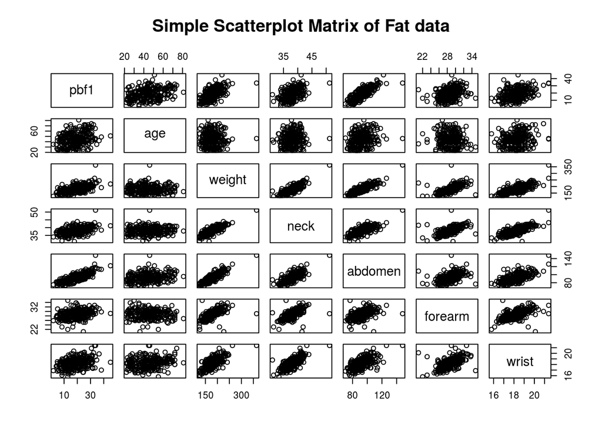

Figure 2.1: Pairs plot of Body Fat data

We will fit a linear regression model of the form

$$\begin{multline}
pbf1_i= \beta_0+\beta_1\textrm{age}_i+\beta_2\textrm{weight}_i+\beta_3\textrm{height}_i+\beta_4\textrm{neck}_i \\
+\beta_5\textrm{chest}+\beta_6\textrm{abdomen}_i+\beta_7\textrm{hip}_i+\beta_8\textrm{thigh}_i+\beta_9\textrm{knee}_i \\
+\beta_{10}\textrm{ankle}_i+ \beta_{11}\textrm{bicep}_i +\beta_{12}\textrm{forearm}_i +\beta_{13}\textrm{wrist}_i + \varepsilon
\end{multline}$$

# 3 Results

|  |  | B | CI | p |
| --- | --- | --- | --- | --- |
| (Intercept) |  | -12.39 | -44.26 – 19.48 | .445 |
| age |  | 0.06 | -0.00 – 0.11 | .065 |
| weight |  | -0.07 | -0.17 – 0.02 | .136 |
| height |  | -0.07 | -0.25 – 0.10 | .417 |
| neck |  | -0.43 | -0.86 – -0.01 | .046 |
| chest |  | -0.04 | -0.22 – 0.14 | .668 |
| abdomen |  | 0.89 | 0.73 – 1.05 | <.001 |
| hip |  | -0.20 | -0.47 – 0.06 | .135 |
| thigh |  | 0.21 | -0.05 – 0.48 | .114 |
| knee |  | -0.02 | -0.46 – 0.43 | .946 |
| ankle |  | 0.15 | -0.25 – 0.56 | .458 |
| bicep |  | 0.17 | -0.15 – 0.48 | .295 |
| forearm |  | 0.42 | 0.05 – 0.78 | .025 |
| wrist |  | -1.49 | -2.47 – -0.52 | .003 |
| Observations |  | 251 |  |  |
| R<sup>2</sup> / adj. R<sup>2</sup> |  | .745 / .731 |  |  |

Model diagnostics are shown in Figures 3.1 and 3.2

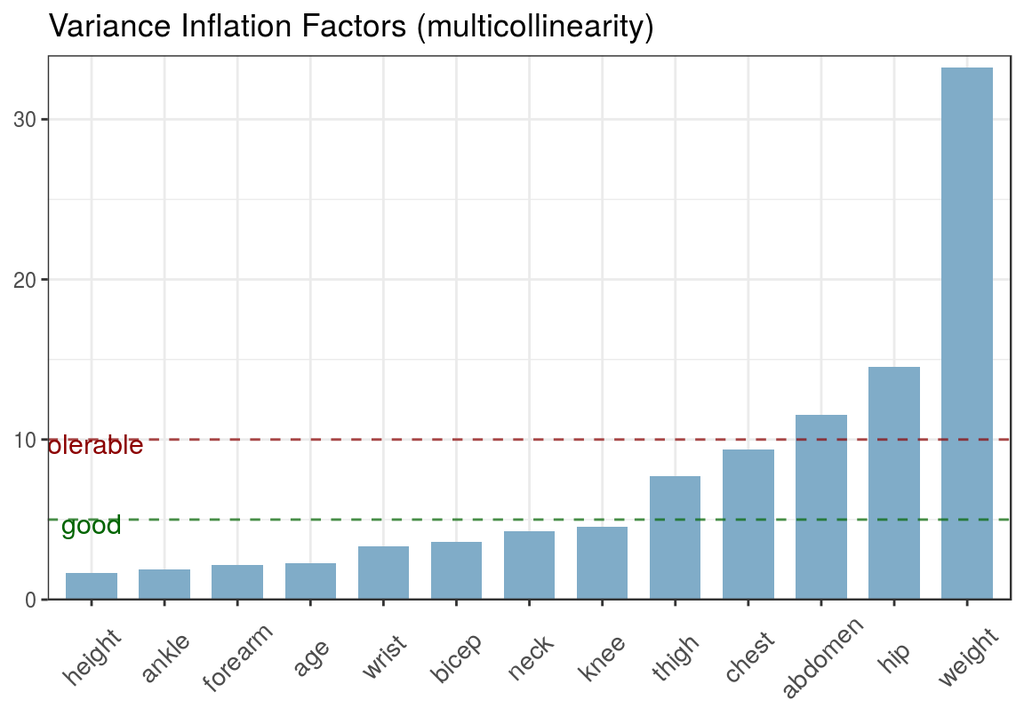

Figure 3.1: Diagnostic 1

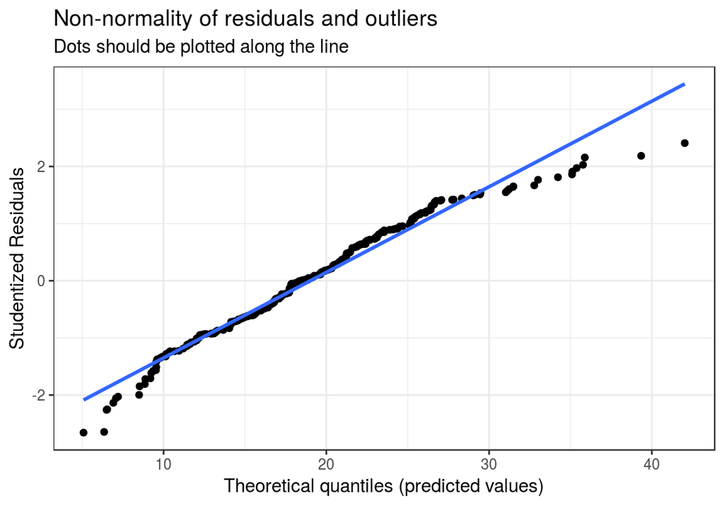

Figure 3.1: Diagnostic 2

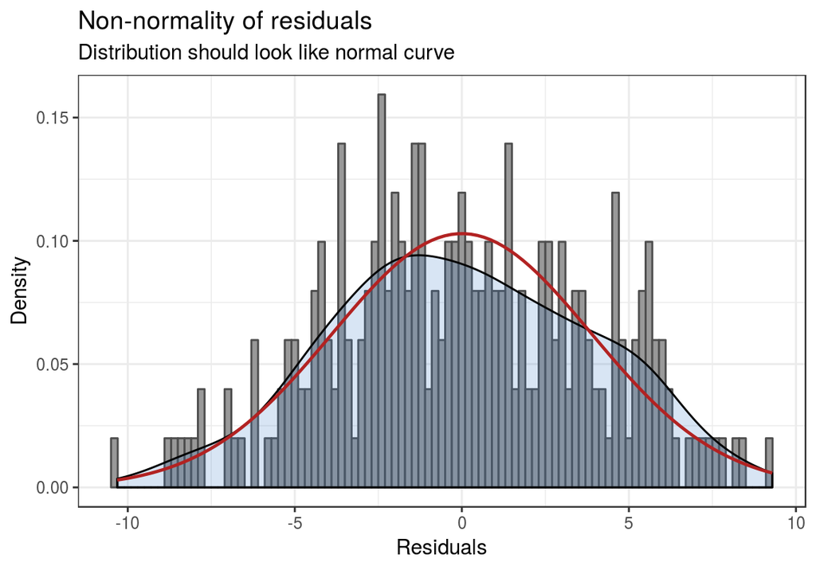

Figure 3.1: Diagnostic 3

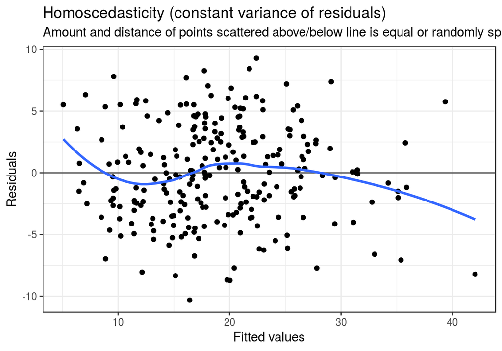

Figure 3.1: Diagnostic 4

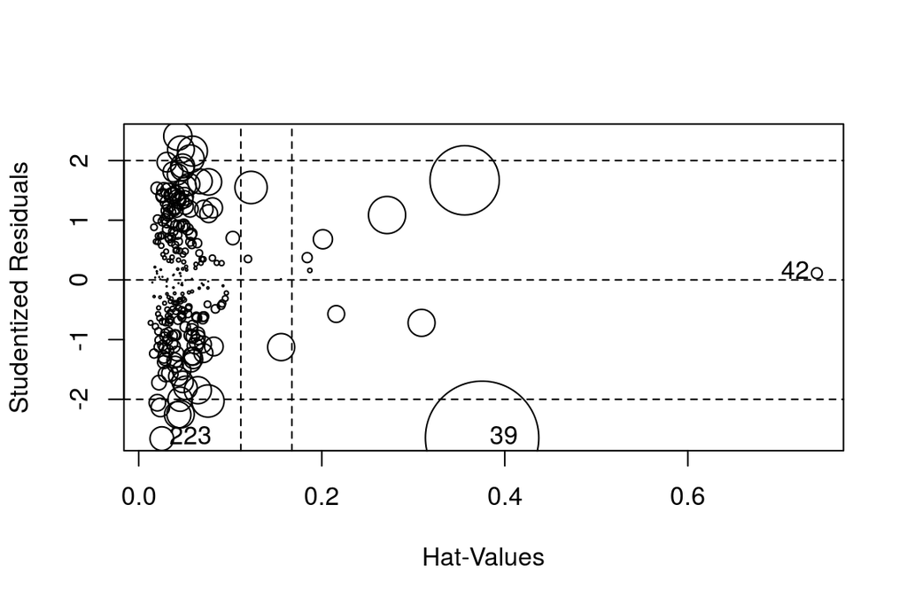

Figure 3.2: Regression influence plot

Look more closely at observation 42:

| pbf1 | weight | height |
| --- | --- | --- |
| 31.7 | 205 | 29.5 |

It’s unlikely someone weighs 205 pounds and only has a height of 29.5 inches.

# 4 Sensitivity Analysis

We perform the same analysis as above, but with observation 42 removed

We compare both fits in the following table:

|  |  | B (CI) |  | B (CI) |
| --- | --- | --- | --- | --- |
| (Intercept) |  | -12.39 (-44.26 – 19.48) |  | -13.85 (-54.77 – 27.06) |
| age |  | 0.06 (-0.00 – 0.11) |  | 0.06 (-0.00 – 0.11) |
| weight |  | -0.07 (-0.17 – 0.02) |  | -0.08 (-0.19 – 0.04) |
| height |  | -0.07 (-0.25 – 0.10) |  | -0.06 (-0.38 – 0.27) |
| neck |  | -0.43 (-0.86 – -0.01) * |  | -0.43 (-0.86 – 0.00) |
| chest |  | -0.04 (-0.22 – 0.14) |  | -0.04 (-0.23 – 0.15) |
| abdomen |  | 0.89 (0.73 – 1.05) *** |  | 0.89 (0.73 – 1.06) *** |
| hip |  | -0.20 (-0.47 – 0.06) |  | -0.20 (-0.47 – 0.07) |
| thigh |  | 0.21 (-0.05 – 0.48) |  | 0.22 (-0.05 – 0.48) |
| knee |  | -0.02 (-0.46 – 0.43) |  | -0.02 (-0.47 – 0.43) |
| ankle |  | 0.15 (-0.25 – 0.56) |  | 0.15 (-0.25 – 0.56) |
| bicep |  | 0.17 (-0.15 – 0.48) |  | 0.17 (-0.15 – 0.48) |
| forearm |  | 0.42 (0.05 – 0.78) * |  | 0.42 (0.05 – 0.78) * |
| wrist |  | -1.49 (-2.47 – -0.52) ** |  | -1.49 (-2.47 – -0.51) ** |
| Observations |  | 251 |  | 250 |
| R<sup>2</sup> / adj. R<sup>2</sup> |  | .745 / .731 |  | .742 / .728 |
| Notes | * p<.05 ** p<.01 *** p<.001 |  |  |  |

# References

Johnson, Roger W. 1996. “Fitting Percentage of Body Fat to Simple Body Measurements.” *Journal of Statistics Education* 4 (1): 265–66.

Penrose, Keith W, AG Nelson, and A Garth Fisher. 1985. “GENERALIZED Body Composition Prediction Equation for Men Using Simple Measurement Techniques.” *Medicine & Science in Sports & Exercise* 17 (2). LWW: 189.